# Hierarchical Bayesian Models

Steve Elston

2023-12-05

# Introduction

Many real-world datasets have discrete categories or strata

- Example, a chemist might measure a reaction rate at several discrete levels of pH and temperature
- Example, demographic categories and different regions
- Apply an hierarchical Bayes model for these situations

# Introduction

Key points in this lesson:

1. Pooled vs. unpooled models
2. Defining hierarchical models through hyperpriors and priors
3. Evaluation and comparison of Bayesian models

# Pooled vs. Unpooled Models

Pooled model computes model coefficients that give the best fit to the overall dataset

- Pooled model has a flat structure
- Model coefficients are at the same level
- Pooling maximizes statistical power using all available data to fit a model
- Pooling limits flexibility if strata have different behavior

# Pooled vs. Unpooled Models

Unpooled models are the opposite of pooled models

- For each category a separate and independent model is fit
- Approach maximizes flexibility
- Variance of each of the, many, models ise large
- Unpooled models has a flat structure

# Overview of Hierarchical Models

Hierarchical models find the best of both worlds

- Hierarchical approach is between the extremes of pooled and unpooled models
- Hierarchical models constructed as a hierarchy of hyperpriors
- The Hyperpriors represent the prior information on the pooled data
- Hyperpriors act as priors for each specific case

# Example: Dangers of Radon in Homes

The unstable isotope Radon-222 is an invisible and order-less gas

$Rn_{222}$ is the product of a nuclear decay chain of Uranium 238

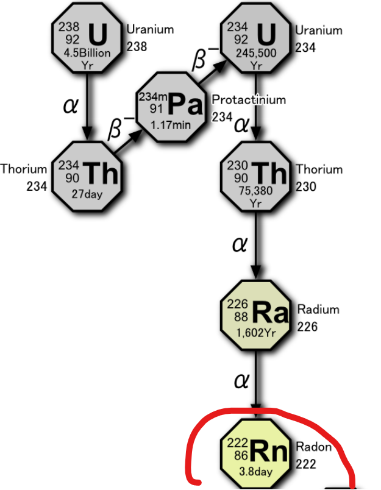

Decay chain of Uranium-238 to Radon-222

Credit: [Wilipedia Radon-222 article!](https://en.wikipedia.org/wiki/Radon-222)

# Example: Dangers of Radon in Homes

Depending on rock and soil type, trace amounts of Uranium-238 are present

- Uranium is [effectively transported by ground water](https://www.nrc.gov/docs/ML0931/ML093160829.pdf)
- Decay products, including $Rn_{222}$, are dispersed in the environment
- Health risk of Radon infiltration into homes is [well-documented](https://www.epa.gov/radon/health-risk-radon)
- $Rn_{222}$ is the most prevalent cause of lung cancer amount US nonsmokers
- Outdoors, $Rn_{222}$ does not accumulate in dangerous quantity

# Example: Dangers of Radon in Homes

Depending on rock and soil type, trace amounts of Uranium-238 are present

- In poorly ventilated buildings, Radon gas accumulates to dangerous levels
- $Rn_{222}$ molecule is heavy, and accumulates in low areas, such as basements
- Connections to wells or contact with ground water accumulate more dangerous levels of Radon

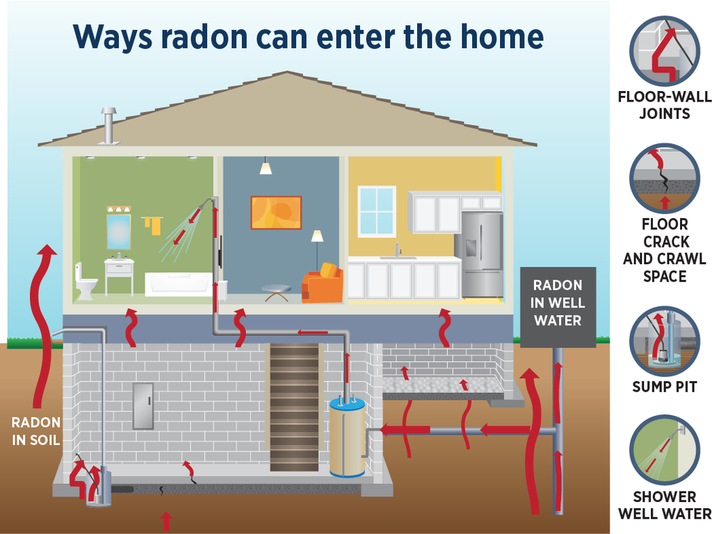

Common ways Radon-222 enters homes

Credit: [Massachusetts Department of Public Health!](https://matracking.ehs.state.ma.us/Environmental-Data/radon/radon_lessons.html)